# Assignment 3

## Exercise 1: Map Scatter Plots to Correlation Coefficients

| Dataset | Correlation coefficient $r_{XY}$ |
| --- | --- |
| $X_3$ | -0.918685 |
| $X_1$ | -0.529351 |
| $X_4$ | 0.72369 |
| $X_2$ | 0.0659047 |

## Exercise 2: Hierarchical Clustering

### 2.1.

*calculations below* a) step one

|  | $p_1$ | $p_2$ | $p_3$ | $p_4$ | $p_5$ |
| --- | --- | --- | --- | --- | --- |
| $p_1$ | 0 | 2.24 | 4.03 | 5.10 | 3.61 |
| $p_2$ |  | 0 | 3.35 | 4.12 | 2.0 |
| $p_3$ |  |  | 0 | 1.12 | 1.8 |
| $p_4$ |  |  |  | 0 | 2.24 |
| $p_5$ |  |  |  |  | 0 |

b) step 2

|  | $p_1$ | $p_2$ | $\{p_3,p_4\}$ | $p_5$ |
| --- | --- | --- | --- | --- |
| $p_1$ | 0 | 2.24 | 4.03 | 3.61 |
| $p_2$ |  | 0 | 3.35 | 2.0 |
| $\{p_3,p_4\}$ |  |  | 0 | 1.8 |
| $p_5$ |  |  |  | 0 |

c) step 3

|  | $p_1$ | $p_2$ | $\{p_3,p_4,p_5\}$ |
| --- | --- | --- | --- |
| $p_1$ | 0 | 2.24 | 3.61 |
| $p_2$ |  | 0 | 2.0 |
| $\{p_3,p_4,p_5\}$ |  |  | 0 |

step 4

|  | $p_1$ | $\{p_2,p_3,p_4,p_5\}$ |
| --- | --- | --- |
| $p_1$ | 0 | 2.24 |
| $\{p_2,p_3,p_4,p_5\}$ |  | 0 |

step 5: $ C = \{p_1,p_2,p_3,p_4,p_5\}$ with $d(C) = 2.24$

d)

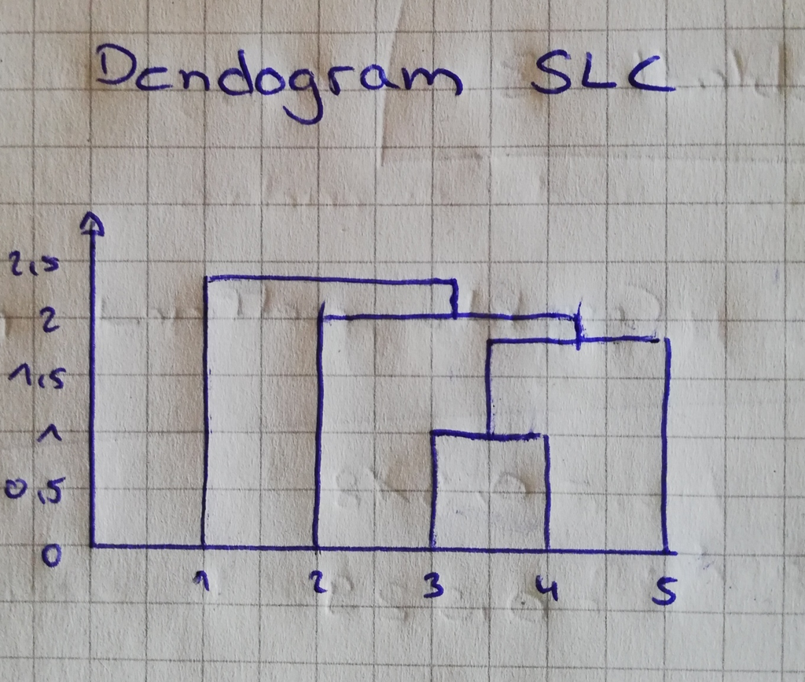

### 2.2.

CLC:

|  | $p_1$ | $p_2$ | $p_3$ | $p_4$ | $p_5$ |
| --- | --- | --- | --- | --- | --- |
| $p_1$ | 0 | 2.24 | 4.03 | 5.10 | 3.61 |
| $p_2$ |  | 0 | 3.35 | 4.12 | 2.0 |
| $p_3$ |  |  | 0 | 1.12 | 1.8 |
| $p_4$ |  |  |  | 0 | 2.24 |
| $p_5$ |  |  |  |  | 0 |

|  | $p_1$ | $p_2$ | $\{p_3,p_4\}$ | $p_5$ |
| --- | --- | --- | --- | --- |
| $p_1$ | 0 | 2.24 | 5,10 | 3.61 |
| $p_2$ |  | 0 | 4.12 | 2.0 |
| $\{p_3,p_4\}$ |  |  | 0 | 2.24 |
| $p_5$ |  |  |  | 0 |

|  | $p_1$ | $\{p_2,p_5\}$ | $\{p_3,p_4\}$ |
| --- | --- | --- | --- |
| $p_1$ | 0 | 3.61 | 5,1 |
| $\{p_2,p_5\}$ |  | 0 | 4,12 |
| $\{p_3,p_4\}$ |  |  | 0 |

|  | $\{p_1,p_2,p_5\}$ | $\{p_3,p_4\}$ |
| --- | --- | --- |
| $\{p_1,p_2,p_5\}$ | 0 | 5.1 |
| $\{p_3,p_4\}$ |  | 0 |

$ C = \{p_1,p_2,p_3,p_4,p_5\}$ with $d(C) = 5.1$

=> Figure (b) => Dendogram 2

### 2.3.

a)

|  | $p_1$ | $p_2$ | $p_3$ | $p_4$ | $p_5$ |
| --- | --- | --- | --- | --- | --- |
| $p_1$ | 0 | 2.24 | 4.03 | 5.10 | 3.61 |
| $p_2$ |  | 0 | 3.35 | 4.12 | 2.0 |
| $p_3$ |  |  | 0 | 1.12 | 1.8 |
| $p_4$ |  |  |  | 0 | 2.24 |
| $p_5$ |  |  |  |  | 0 |

Center of P3 + P4: (1.75, 5.5)

|  | $p_1$ | $p_2$ | $\{p_3,p_4\}$ | $p_5$ |
| --- | --- | --- | --- | --- |
| $p_1$ | 0 | 2.24 | 4,56 | 3.61 |
| $p_2$ |  | 0 | 3,71 | 2.0 |
| $\{p_3,p_4\}$ |  |  | 0 | 1.95 |
| $p_5$ |  |  |  | 0 |

Center of P3,P4 + P5: (2.375, 4.75)

|  | $p_1$ | $p_2$ | $\{p_3,p_4,p_5\}$ |
| --- | --- | --- | --- |
| $p_1$ | 0 | 2.24 | 3.99 |
| $p_2$ |  | 0 | 2.82 |
| $\{p_3,p_4,p_5\}$ |  |  | 0 |

Center of P1 + P2: (2.0, 1.5)

|  | $\{p_1,p_2\}$ | $\{p_3,p_4,p_5\}$ |
| --- | --- | --- |
| $\{p_1,p_2\}$ | 0 | 3.27 |
| $\{p_2,p_3,p_4,p_5\}$ |  | 0 |

Center of P1,P2 + P3,P4,P5: (2.1875, 3.125)

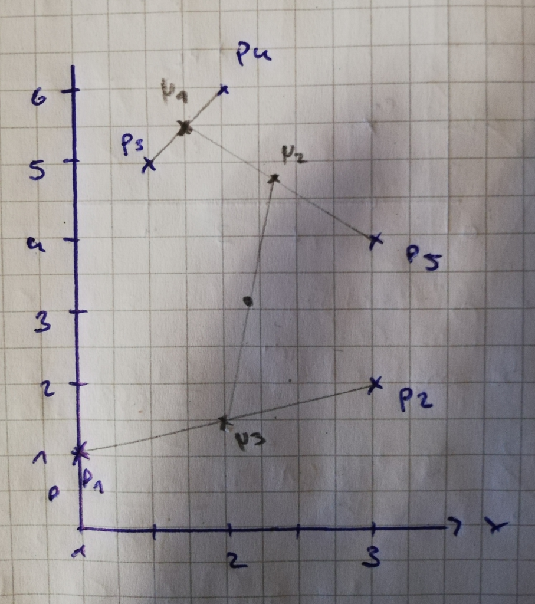

d) Dendogram 1

## Exercise 3: Comparison of Different Linkages

### 3.3

1. Explain for the single-linkage and complete-linkage inter-cluster distances how the clusters in 𝑘 = 2 arise. Start with the clusters in 𝑘 = 3 and explain the merge from 𝑘 = 3 to 𝑘 = 2.
- *single-linkage*: The yellow dot is the the furthest away from all other dots. Thus it stays a separate cluster while the blue ring (for k=3) has data points closer to a point from the big purple cluster and gets incorporated.
- *complete-linkage*: The furthest point in the blue cluster is closer to the yellow cluster than the furthest point of the purple cluster. Thus the two upper clusters are merged.

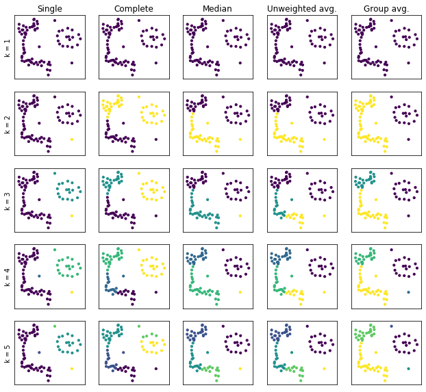

```python
import pickle
from scipy.cluster.hierarchy import linkage, fcluster
import matplotlib.pyplot as plt

data = pickle.load(open('data.pickle', 'rb'))

links = ['single', 'complete', 'median', 'weighted', 'average']
link_names = ['Single', 'Complete', 'Median', 'Unweighted avg.', 'Group avg.']

fig, axs = plt.subplots(5,5,sharex=True, sharey=True)
fig.subplots_adjust(top=2,right=1.5) # enlarge individual plots

for k in range(1,6):
    for i in range(len(links)):
        # Apply the agglomerative algorithm to obtain the hierarchyinformation
        tree = linkage(data, method=links[i], optimal_ordering=True)

        # Undo the last merges to retrieve at most k clusters
        labels = fcluster(tree, k, criterion='maxclust')

        axs[k-1,i].scatter(data[:,0],data[:,1], c=labels, s=10)
        axs[k-1,i].axes.xaxis.set_ticks([]) # turn off axis values and ticks
        axs[k-1,i].axes.yaxis.set_ticks([]) # turn off axis values and ticks

        # generate labels at the side
        if k == 1:
            axs[k-1,i].set_title(link_names[i])
        if i == 0:
            axs[k-1,i].set_ylabel(f'k = {k}')
plt.show()
```

```python
import numpy as np

p1 = (1,1)
p2 = (3,2)
p3 = (1.5,5)
p4 = (2,6)
p5 = (3,4)

def dist(a,b): # calculates euclidian distance of tuples a and b
    return np.sqrt((a[0]-b[0])**2 + (a[1]-b[1])**2)

def center(a,b):
    centerX = (a[0]+b[0])/2
    centerY = (a[1]+b[1])/2
    return (centerX, centerY)

print("dist p1,p4: ", dist(p1,p4))
print("dist p2,p5: ", dist(p2,p5))

centerP3_P4 = center(p3,p4)
print("\ncenter: p3,p4:", centerP3_P4)
print("dist centerP3_P4, p1: ", dist(centerP3_P4, p1))
print("dist centerP3_P4, p2: ", dist(centerP3_P4, p2))
print("dist centerP3_P4, p5: ", dist(centerP3_P4, p5))

centerP3_P4_P5 = center(centerP3_P4,p5)
print("\ncenter: centerP3_P4_P5:", centerP3_P4_P5)
print("dist centerP3_P4_P5, p1: ", dist(centerP3_P4_P5, p1))
print("dist centerP3_P4_P5, p2: ", dist(centerP3_P4_P5, p2))

centerP1_p2 = center(p1,p2)
print("\ncenter: centerP1_p2:", centerP1_p2)
print("dist centerP1_p2, centerP3_P4_P5: ", dist(centerP3_P4_P5, centerP1_p2))

centerAll = center(centerP1_p2,centerP3_P4_P5)
print("\ncenter: centerAll:", centerAll)
```

```
dist p1,p4:  5.0990195135927845
dist p2,p5:  2.0

center: p3,p4: (1.75, 5.5)
dist centerP3_P4, p1:  4.562071897723665
dist centerP3_P4, p2:  3.7165171868296265
dist centerP3_P4, p5:  1.9525624189766635

center: centerP3_P4_P5: (2.375, 4.75)
dist centerP3_P4_P5, p1:  3.9941363271676145
dist centerP3_P4_P5, p2:  2.8201285431696195

center: centerP1_p2: (2.0, 1.5)
dist centerP1_p2, centerP3_P4_P5:  3.2715630820756

center: centerAll: (2.1875, 3.125)
```